# Representación de datos con PCA en R

# 1. Introducción

- Muchos problemas tienen decenas de variables, difíciles de visualizar y a menudo **redundantes** (correlacionadas).
- El **Análisis de Componentes Principales** (PCA) resume esa información en unas pocas variables nuevas (las *componentes*), combinaciones lineales de las originales.
- La 1.ª componente apunta en la dirección de **máxima varianza**; las siguientes son ortogonales y captan la varianza restante.
- Es un método **no supervisado**: solo usa las características, no un *outcome*.

# 2. Datos

- Reutilizamos los datos de cáncer de seno de la sesión 1 (`wisc_bc_data.csv`), con 30 variables numéricas que describen el núcleo celular.

```r
wbcd <- read.csv("data/wisc_bc_data.csv", stringsAsFactors = FALSE)
```

- La columna 1 es un identificador y la 2 el diagnóstico (`B`/`M`). Las 30 características numéricas están en las columnas 3 a 32. Guardamos el diagnóstico aparte (solo para colorear al final; PCA **no** lo usa):

```r
diagnosis <- factor(wbcd$diagnosis, levels = c("B", "M"), labels = c("Benigno", "Maligno"))
features <- wbcd[, 3:32]
```

# 3. Aplicar PCA

- Usamos `prcomp()` de R base. Como las variables están en escalas muy distintas, fijamos `scale. = TRUE` para estandarizarlas:

```r
pca <- prcomp(features, scale. = TRUE)
```

- `summary()` muestra la varianza explicada por cada componente y la acumulada:

```r
summary(pca)
```

```
## Importance of components:
##                           PC1    PC2     PC3     PC4     PC5     PC6     PC7
## Standard deviation     3.6444 2.3857 1.67867 1.40735 1.28403 1.09880 0.82172
## Proportion of Variance 0.4427 0.1897 0.09393 0.06602 0.05496 0.04025 0.02251
## Cumulative Proportion  0.4427 0.6324 0.72636 0.79239 0.84734 0.88759 0.91010
##                            PC8    PC9    PC10   PC11    PC12    PC13    PC14
## Standard deviation     0.69037 0.6457 0.59219 0.5421 0.51104 0.49128 0.39624
## Proportion of Variance 0.01589 0.0139 0.01169 0.0098 0.00871 0.00805 0.00523
## Cumulative Proportion  0.92598 0.9399 0.95157 0.9614 0.97007 0.97812 0.98335
##                           PC15    PC16    PC17    PC18    PC19    PC20   PC21
## Standard deviation     0.30681 0.28260 0.24372 0.22939 0.22244 0.17652 0.1731
## Proportion of Variance 0.00314 0.00266 0.00198 0.00175 0.00165 0.00104 0.0010
## Cumulative Proportion  0.98649 0.98915 0.99113 0.99288 0.99453 0.99557 0.9966
##                           PC22    PC23   PC24    PC25    PC26    PC27    PC28
## Standard deviation     0.16565 0.15602 0.1344 0.12442 0.09043 0.08307 0.03987
## Proportion of Variance 0.00091 0.00081 0.0006 0.00052 0.00027 0.00023 0.00005
## Cumulative Proportion  0.99749 0.99830 0.9989 0.99942 0.99969 0.99992 0.99997
##                           PC29    PC30
## Standard deviation     0.02736 0.01153
## Proportion of Variance 0.00002 0.00000
## Cumulative Proportion  1.00000 1.00000
```

- Fíjate en la fila *Cumulative Proportion*: con pocas componentes ya acumulamos buena parte de la varianza de las 30 variables originales.

# 4. ¿Cuántas componentes? (gráfica de sedimentación)

- Calculemos la proporción de varianza que explica cada componente y grafiquémosla (*scree plot*):

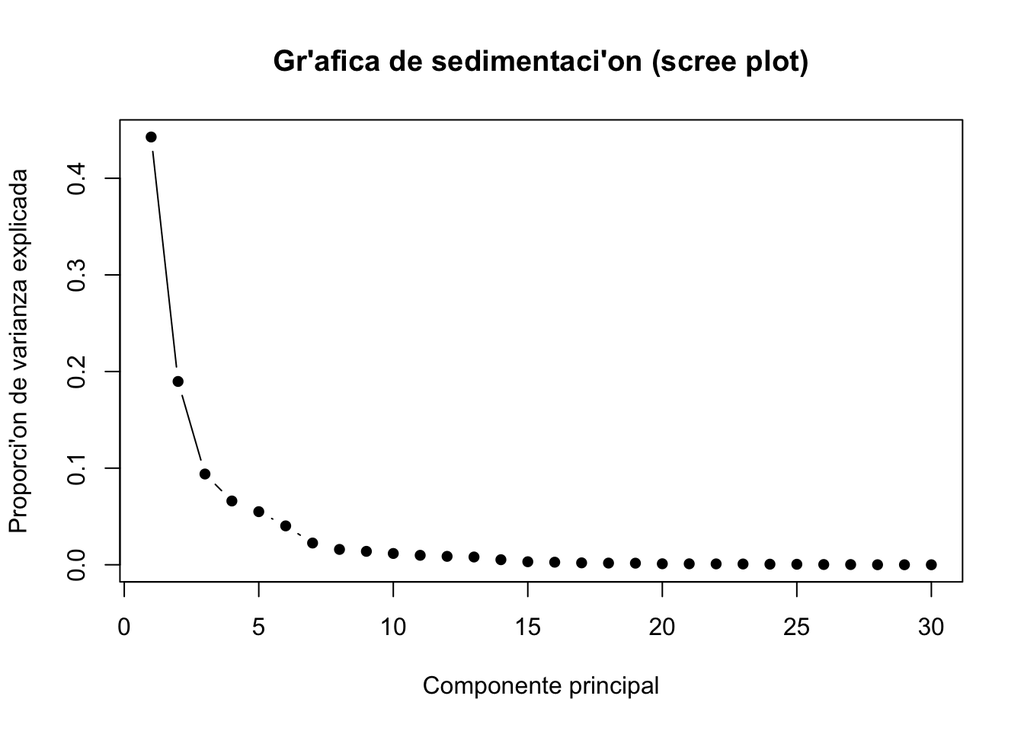

```r
ve <- pca$sdev^2 / sum(pca$sdev^2)
plot(ve, type = "b", pch = 16,
     xlab = "Componente principal", ylab = "Proporción de varianza explicada",
     main = "Gráfica de sedimentación (scree plot)")
```

- La varianza acumulada de las primeras componentes:

```r
round(cumsum(ve)[1:5], 3)
```

```
## [1] 0.443 0.632 0.726 0.792 0.847
```

- Nos quedamos con las componentes hasta el “codo”: donde añadir más ya aporta poco.

# 5. Proyección a 2 dimensiones

- Las coordenadas de cada observación en las nuevas componentes están en `pca$x`. Proyectemos los datos en las 2 primeras componentes y coloreemos por diagnóstico:

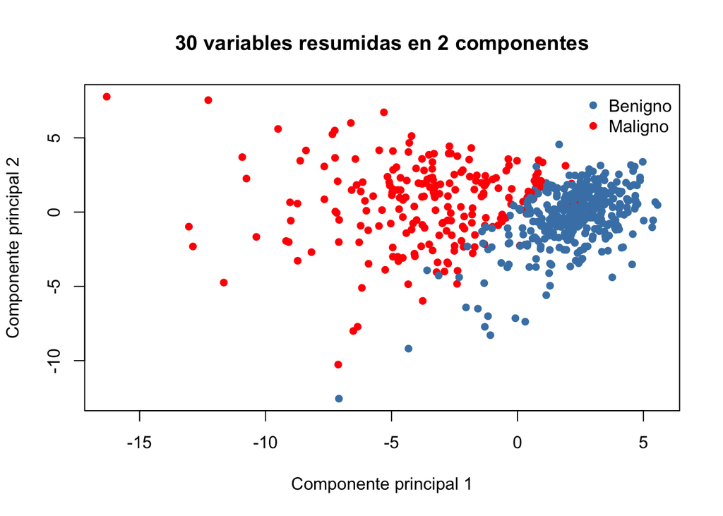

```r
plot(pca$x[, 1], pca$x[, 2], col = c("steelblue", "red")[as.integer(diagnosis)], pch = 16,
     xlab = "Componente principal 1", ylab = "Componente principal 2",
     main = "30 variables resumidas en 2 componentes")
legend("topright", levels(diagnosis), col = c("steelblue", "red"), pch = 16, bty = "n")
```

- Aunque PCA **no** usó el diagnóstico, los casos benignos y malignos quedan en zonas casi separadas: la estructura del problema sobrevive al pasar de 30 a 2 dimensiones.

# 6. Para cerrar

- PCA es **lineal**. Para estructuras no lineales existen métodos como **t-SNE** o **UMAP**, muy usados para visualización.
- Estas representaciones compactas también sirven como **insumo** para modelos supervisados, o para comprimir y visualizar.
- Es la misma idea que, llevada a redes neuronales, da lugar a los **embeddings** (próxima sesión).
- Como ejercicio: usa solo las 2 primeras componentes (`pca$x[, 1:2]`) como predictores de un modelo de clasificación y compara con usar las 30 variables.